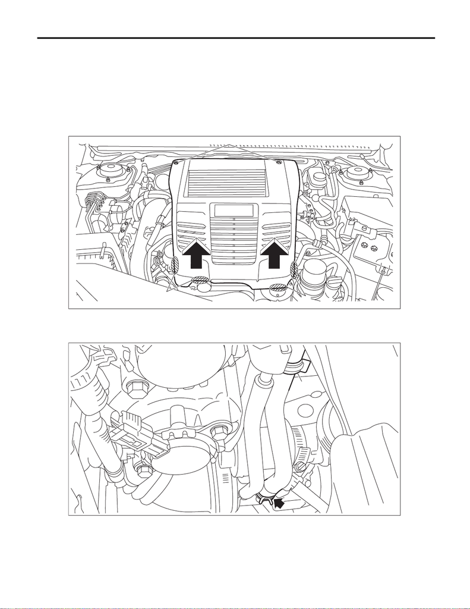

PCV Pipe

EMISSION CONTROL (AUX. EMISSION CONTROL DEVICES)

13.PCV Pipe

A: REMOVAL

CAUTION:

Do not remove except when the PCV pipe is broken.

1) Remove the collector cover.

(1) Remove the clips (A).

(2) Hold the shaded area (B) by hand and carefully pull the RH side (C) upward.

(3) Hold the shaded area (D) by hand and carefully pull the LH side (E) upward.

2) Collect the refrigerant from A/C system. <Ref. to AC-26, Refrigerant Recovery Procedure.>

3) Disconnect the ground terminal from battery sensor. <Ref. to NT-5, BATTERY, NOTE, Note.>

4) Disconnect the PCV pipe from the intake duct No. 1, and remove the clip (A) from the PCV pipe.

(A)

(B)

(C)

(E)

(D)

(A)

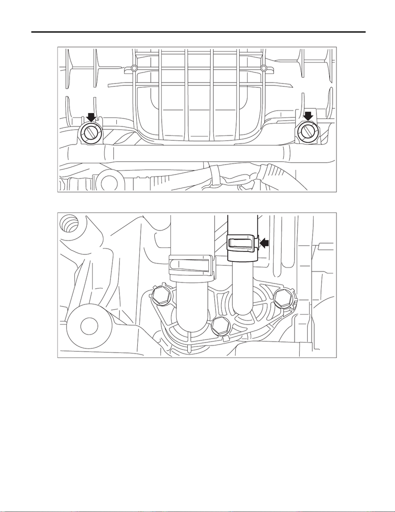

PCV Pipe

EMISSION CONTROL (AUX. EMISSION CONTROL DEVICES)

5) Remove the clip securing the PCV pipe to the intake manifold.

6) Remove the A/C compressor. <Ref. to AC-45, REMOVAL, Compressor.>

7) Remove the PCV pipe from the PCV connector.

B: INSTALLATION

Install in the reverse order of removal.

C: INSPECTION

Check that the PCV pipe has no cracks, damage or loose part.